# Fall 2021 - Math 421 - Midterm

[figure not shown]

```r
df18$er_mode = factor(df18$er_mode)
graph10 = df18 %>%  filter(provider == "7205", er_chrg>0) %>%ggplot() + geom_bar(mapping = aes(x = er_mode)) + labs(x='ER Admisson Type',
       y = 'Total Patients',
       title = 'Rhode Island Hospital ER Admissions',
       caption = 'The majority of ER admissions at Rhode Island Hospital were admitted by an ambulance.')

ggsave(filename = 'graph10.png', plot = graph10)
graph10
```

2. Make an animation plot.

[figure not shown]

```r
library(gganimate)
library(ggplot2)

animate_graph = df18 %>% filter(provider %in% c("7205", "7204", "7214")) %>%  group_by(moa, provider) %>% summarize(avg_cost = mean(tot))  %>% ggplot(aes(x = moa, y = avg_cost, color = provider)) + geom_line()+ transition_reveal(moa)

ggsave(filename = 'animate_graph.png', plot = animate_graph)
animate_graph
```

3. Write a paragraph to summarize the section and give your comments on the results.

The dynamic of the hospitals in Rhode Island is full of interesting information. I first looked at the cost of visits by age and sex of the patients in 2018, and I saw that both had peaks around the ages of 12 and 65. Mainly, I looked at hospital provider. The issue with the way the data classifies the provider is that when R reads them in, they see the numbers as numeric values rather than classification. To solve this, I had to make providers factor variables. Rhode Island Hospital had the most patients admitted with over 35000 admissions. The next largest hospital did not break 20000. On of the most interesting graphs I made was to compare the amount of in-state and out-of-state patients for each hospital. I found that Westerly Hospital had a lower percent of in-state patients by a wide margin. This is probably because it borders CT, so more CT people go there if it’s closer instead of further ones in CT. I wanted to look at service as a feature, but there were mostly 00, which means they have no classification for service.

## III. Predictive Models

Continue with the data from part I. Use the follows as the target and input variables:

*Target Variable*: Create the target variable taking value of

- `low` if the total charge of a patient (`tot`) is smaller than the median of the total charge, and
- `high` otherwise.

```r
med_tot = median(df18$tot)
df18$target = ifelse(df18$tot < med_tot, "low", "high")
```

*Input Variables*:

- “age”,“sex”,“raceethn”,“provider”,“moa”,“mod”,“admtype”,“campus”, ‘los’

```r
df18_var = df18[,c("age","sex","raceethn","provider","moa","mod","admtype","campus", 'los', "target")]
```

1. Use `filter` function to filter out rows where `raceethn==''` or `admtype==''`. Make sure all the categorical variables are factor, numeric variables are numeric. Set Training : Testing Split = 10 : 90

```r
df18_var$sex = factor(df18_var$sex)
df18_var$provider = factor(df18_var$provider)
df18_var$raceethn = factor(df18_var$raceethn)
df18_var$admtype = factor(df18_var$campus)
df18_var$target = factor(df18_var$target)
df18_var$moa = factor(df18_var$moa)
df18_var$mod = factor(df18_var$mod)
df18_var = df18_var %>% filter(raceethn != "", admtype!='')

library(caret)
set.seed(2020)
splitIndex <- createDataPartition(df18_var$target, p = .10, list = FALSE)
df_train <- df18_var[ splitIndex,]
df_test <- df18_var[-splitIndex,]
```

2. Train a decision tree using `rpart`. Plot the decision tree. Plot the variable importance ranked by the tree.

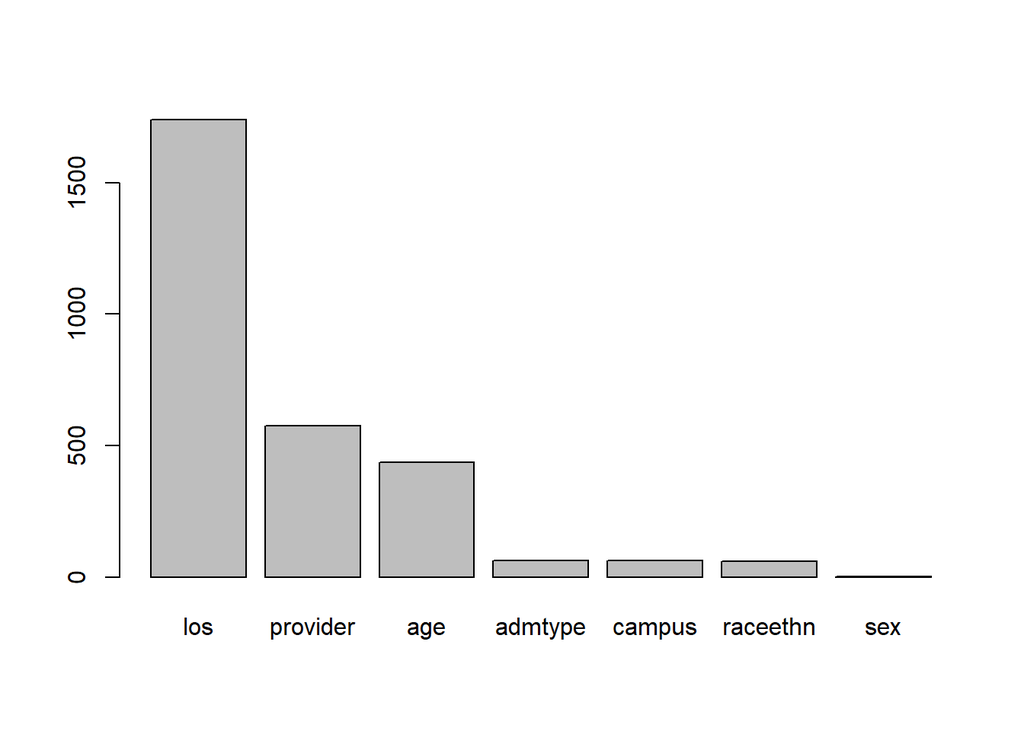

```r
library(rpart)
tree_model <- rpart(target ~ ., data = df_train)
barplot(tree_model$variable.importance)
```

3. Using caret for this question. Set `Training Control` to be: Use Cross-Validation of 5 folds across all models. Train & tune at least 3 different models (i.e. three different values for `method=` in the train function of caret). Plot the hyper-parameter tuning plots for each model.

```r
trControl = trainControl(method = "cv",
                         number = 5)

tuneTree = expand.grid(maxdepth = 2:4)

tree <- train(target~., data=df_train,
                                method = "rpart2",
                                trControl = trControl,
              tuneGrid = tuneTree)

tuneForest = expand.grid(mtry = 2:4,
                       splitrule = c('gini'),
                       min.node.size = c(1:10))

forest_ranger <- train(target~., data=df_train,
                    method = "ranger",
                                trControl = trControl,
                    tuneGrid = tuneForest)

tuneKNN = expand.grid(k = 5:8)

knn <- train(target~., data=df_train,
                                method = "knn",
                                trControl = trControl,
                                tuneGrid= tuneKNN)

results <- resamples(list('Decision Tree' = tree,
                          'Random Forest' = forest_ranger,
                          'knn'= knn))
```

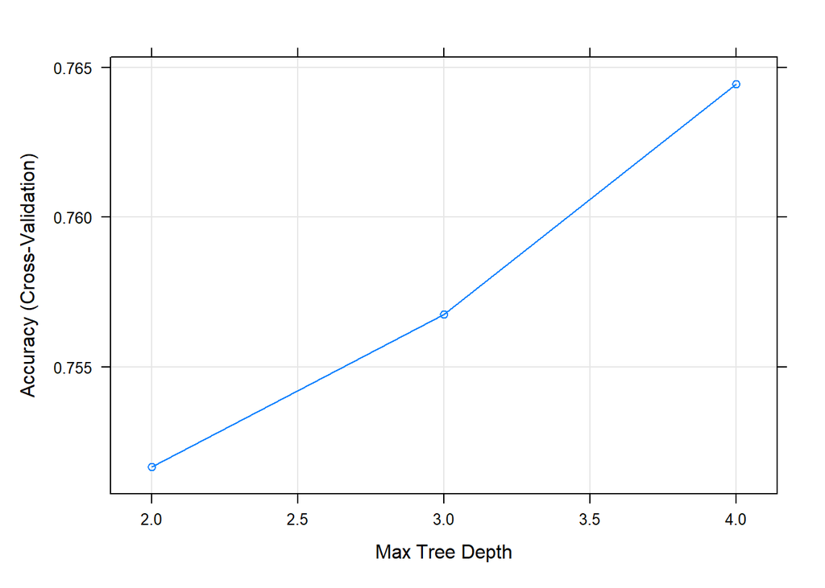

```r
plot(tree)
```

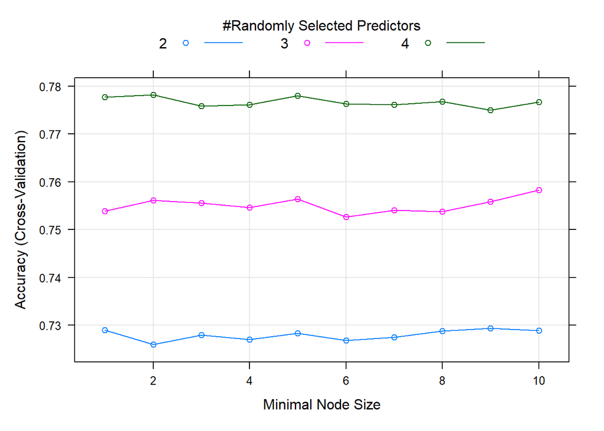

```r
plot(forest_ranger)
```

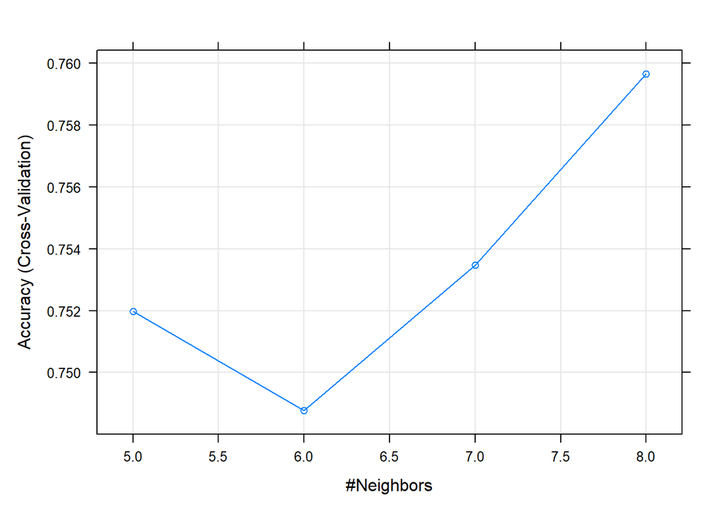

```r
plot(knn)
```

4. Plot the comparison of the models in 3.

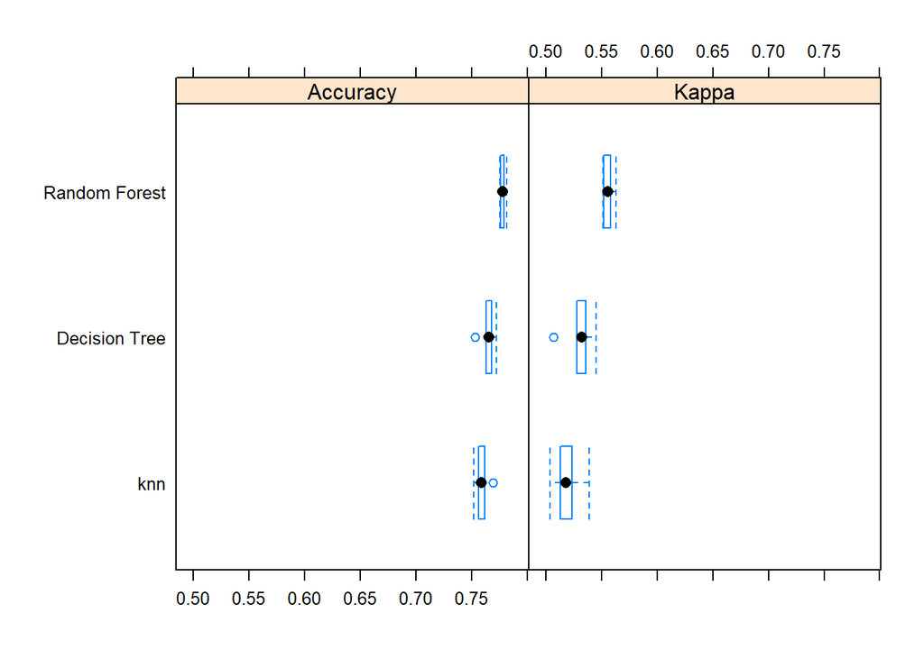

```r
bwplot1 = bwplot(results)
bwplot1
```

The random forest has the highest mean value for accuracy and kappa. This is the modelthat I will use for the final prediction.

5. What is your final selection for the model? Test the accuracy of your final model on the test data.

```r
pred <- predict(forest_ranger, df_test)
#Evaluate the predictions
cm <- confusionMatrix(data = pred, reference = df_test$target, positive = "low")
cm$overall[1]
```

```
##  Accuracy
## 0.7750381
```

6. Create another `target` variable (binary), decide the input variables and redo 1 to 5.

```r
df18_var1 = df18[,c("age","sex","raceethn","provider","moa","mod","admtype","campus", 'los', "tot")]
```

```r
df18_var1$provider = factor(df18_var1$provider)
df18_var1$raceethn = factor(df18_var1$raceethn)
df18_var1$admtype = factor(df18_var1$campus)
df18_var1$moa = factor(df18_var1$moa)
df18_var1$mod = factor(df18_var1$mod)
df18_var1 = df18_var1 %>% filter(raceethn != "", admtype!='', sex != "9")
df18_var1$sex = factor(df18_var1$sex)

library(caret)
set.seed(2020)
splitIndex <- createDataPartition(df18_var1$sex, p = .10, list = FALSE)
df_train <- df18_var[ splitIndex,]
df_test <- df18_var[-splitIndex,]
```

```
2.
```

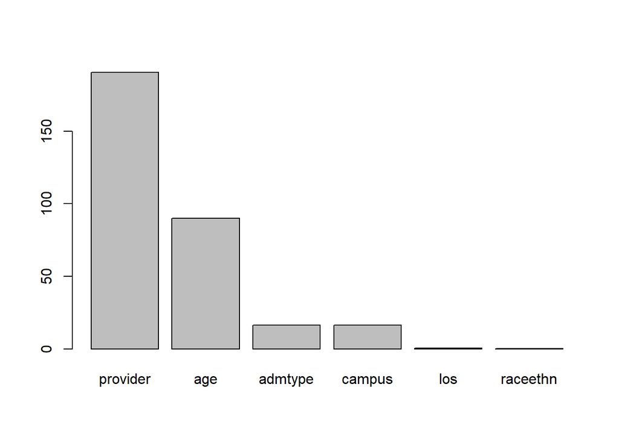

[output not shown]

```r
library(rpart)
tree_model <- rpart(sex ~ ., data = df_train)
barplot(tree_model$variable.importance)
```

```r
trControl = trainControl(method = "cv",
                         number = 5)

tuneTree = expand.grid(maxdepth = 2:4)

tree1 <- train(sex~., data=df_train,
                                method = "rpart2",
                                trControl = trControl,
              tuneGrid = tuneTree)

tuneForest = expand.grid(mtry = 2:4,
                       splitrule = c('gini'),
                       min.node.size = c(1:10))

forest_ranger1 <- train(sex~., data=df_train,
                    method = "ranger",
                                trControl = trControl,
                    tuneGrid = tuneForest)

tuneKNN = expand.grid(k = 5:8)

knn1 <- train(sex~., data=df_train,
                                method = "knn",
                                trControl = trControl,
                                tuneGrid= tuneKNN)

results1 <- resamples(list('Decision Tree' = tree1,
                          'Random Forest' = forest_ranger1,
                          'knn'= knn1))
```

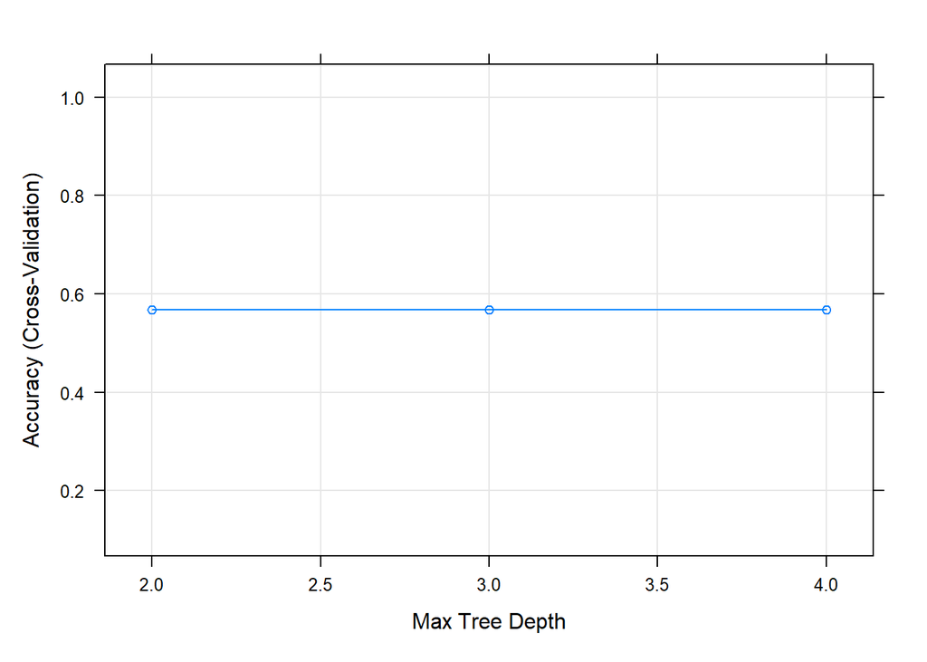

```r
plot(tree1)
```

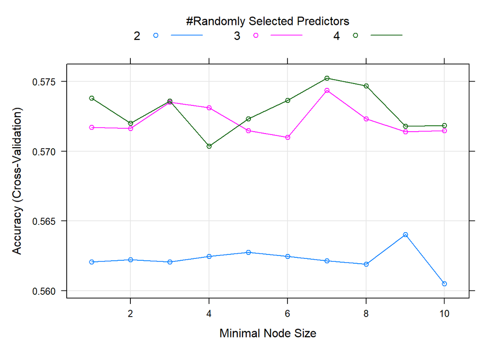

```r
plot(forest_ranger1)
```

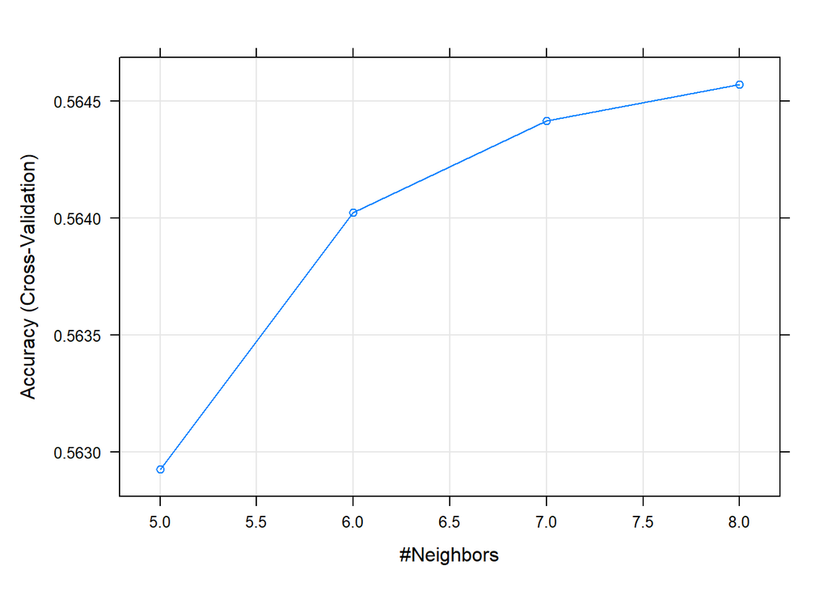

[output not shown]

```r
plot(knn1)
```

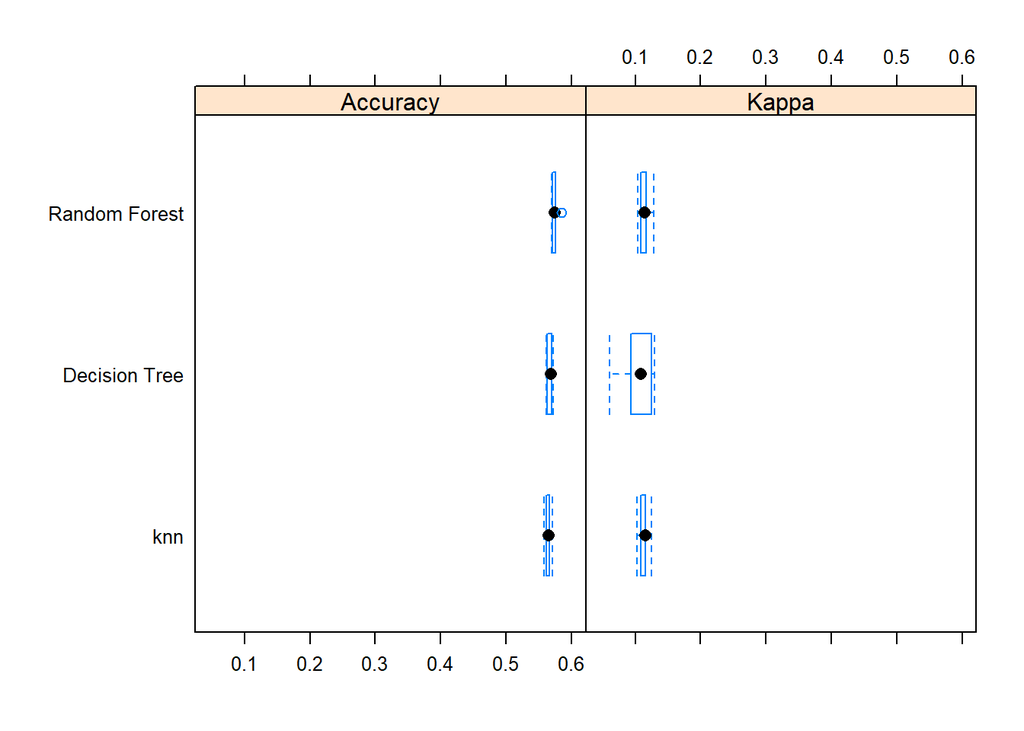

```r
bwplot(results1)
```

None of these models are great, but out of all of them, The random forest has the highest accuracy and the more compact Kappa range.

```
5.
```

```r
pred <- predict(forest_ranger1, df_test)
#Evaluate the predictions
cm <- confusionMatrix(data = pred, reference = df_test$sex, positive = "1")
cm$overall[1]
```

```
##  Accuracy
## 0.5750207
```